# Final Project ML

## 1. 원시 데이터 간편 분석

### 1-가. 데이터 확인 : df.head( ) 함수 이용

```python
import pandas as pd
import numpy as np

df = pd.read_excel("Admission_Predictions.xlsx")

df.head()
```

|  | Serial No. | GRE Score | TOEFL Score | University Rating | SOP | LOR | CGPA | Research | Chance of Admit |
| --- | --- | --- | --- | --- | --- | --- | --- | --- | --- |
| 0 | 1 | 337 | 118 | 4 | 4.5 | 4.5 | 9.65 | 1 | 0.92 |
| 1 | 2 | 324 | 107 | 4 | 4.0 | 4.5 | 8.87 | 1 | 0.76 |
| 2 | 3 | 316 | 104 | 3 | 3.0 | 3.5 | 8.00 | 1 | 0.72 |
| 3 | 4 | 322 | 110 | 3 | 3.5 | 2.5 | 8.67 | 1 | 0.80 |
| 4 | 5 | 314 | 103 | 2 | 2.0 | 3.0 | 8.21 | 0 | 0.65 |

### 1-나. 변수 설명

- Serial No. : 불필요 변수로서 제거 예정
- GRE Score : GRE 대학원 입학 시험 점수 (out of 340)
- TOEFL Score : 토플 시험 점수 (out of 120)
- University Rating : 지원 학생의 소속 대학교 평가점수 (out of 5)
- SOP : Statement of Purpose Strength (out of 5)
- LOR : Letter of Recommendation Strength (out of 5)
- CGPA : 지원 학생의 대학교 내신 성적 GPA (out of 10)
- Research : 리서치 경험 (either 0 or 1)
- Chance of Admit : 입학 가능성 (ranging from 0 to 1)

#### 기타 데이터별 주석

- University Rating : 지원자가 소속된 대학교의 미국 내 순위로서 경쟁자들과 다른 변수가 동일한 경우 대학교 평가 점수의 기여도를 활용할 수 있겠으나 그나마 데이터 양이 적어서 정확도가 미흡
- CGPA : 데이터셋 제공자가 임의 조정하였으며 미 대학원에 지원하는 미국인과 인도인 대학생 기준임
- Research : 대학교 재학 중 리서치 경험 여부를 표시 (Binary component로서 특수 변수)
- Chance of Admit : 입학 승인 가능성 내지는 지원자의 "confidence"로 보는 견해도 있음

### 1-다. 데이터 정보 출력

```python
df.info()
```

```
<class 'pandas.core.frame.DataFrame'>
RangeIndex: 500 entries, 0 to 499
Data columns (total 9 columns):
Serial No.           500 non-null int64
GRE Score            500 non-null int64
TOEFL Score          500 non-null int64
University Rating    500 non-null int64
SOP                  500 non-null float64
LOR                  500 non-null float64
CGPA                 500 non-null float64
Research             500 non-null int64
Chance of Admit      500 non-null float64
dtypes: float64(4), int64(5)
memory usage: 35.3 KB
```

### 1-라. 불필요 컬럼 제외

```python
df = df.drop(columns=['Serial No.'])

df.head()
```

|  | GRE Score | TOEFL Score | University Rating | SOP | LOR | CGPA | Research | Chance of Admit |
| --- | --- | --- | --- | --- | --- | --- | --- | --- |
| 0 | 337 | 118 | 4 | 4.5 | 4.5 | 9.65 | 1 | 0.92 |
| 1 | 324 | 107 | 4 | 4.0 | 4.5 | 8.87 | 1 | 0.76 |
| 2 | 316 | 104 | 3 | 3.0 | 3.5 | 8.00 | 1 | 0.72 |
| 3 | 322 | 110 | 3 | 3.5 | 2.5 | 8.67 | 1 | 0.80 |
| 4 | 314 | 103 | 2 | 2.0 | 3.0 | 8.21 | 0 | 0.65 |

### 1-마. 데이터 전반적 통계적 특성 보기

```python
df.describe()
```

|  | GRE Score | TOEFL Score | University Rating | SOP | LOR | CGPA | Research | Chance of Admit |
| --- | --- | --- | --- | --- | --- | --- | --- | --- |
| count | 500.000000 | 500.000000 | 500.000000 | 500.000000 | 500.00000 | 500.000000 | 500.000000 | 500.00000 |
| mean | 316.472000 | 107.192000 | 3.114000 | 3.374000 | 3.48400 | 8.576440 | 0.560000 | 0.72174 |
| std | 11.295148 | 6.081868 | 1.143512 | 0.991004 | 0.92545 | 0.604813 | 0.496884 | 0.14114 |
| min | 290.000000 | 92.000000 | 1.000000 | 1.000000 | 1.00000 | 6.800000 | 0.000000 | 0.34000 |
| 25% | 308.000000 | 103.000000 | 2.000000 | 2.500000 | 3.00000 | 8.127500 | 0.000000 | 0.63000 |
| 50% | 317.000000 | 107.000000 | 3.000000 | 3.500000 | 3.50000 | 8.560000 | 1.000000 | 0.72000 |
| 75% | 325.000000 | 112.000000 | 4.000000 | 4.000000 | 4.00000 | 9.040000 | 1.000000 | 0.82000 |
| max | 340.000000 | 120.000000 | 5.000000 | 5.000000 | 5.00000 | 9.920000 | 1.000000 | 0.97000 |

## 2. 데이터 변수 간 상관관계

### 2-가. 변수 간 상관관계 측정

```python
df.corr()
```

|  | GRE Score | TOEFL Score | University Rating | SOP | LOR | CGPA | Research | Chance of Admit |
| --- | --- | --- | --- | --- | --- | --- | --- | --- |
| GRE Score | 1.000000 | 0.827200 | 0.635376 | 0.613498 | 0.524679 | 0.825878 | 0.563398 | 0.810351 |
| TOEFL Score | 0.827200 | 1.000000 | 0.649799 | 0.644410 | 0.541563 | 0.810574 | 0.467012 | 0.792228 |
| University Rating | 0.635376 | 0.649799 | 1.000000 | 0.728024 | 0.608651 | 0.705254 | 0.427047 | 0.690132 |
| SOP | 0.613498 | 0.644410 | 0.728024 | 1.000000 | 0.663707 | 0.712154 | 0.408116 | 0.684137 |
| LOR | 0.524679 | 0.541563 | 0.608651 | 0.663707 | 1.000000 | 0.637469 | 0.372526 | 0.645365 |
| CGPA | 0.825878 | 0.810574 | 0.705254 | 0.712154 | 0.637469 | 1.000000 | 0.501311 | 0.882413 |
| Research | 0.563398 | 0.467012 | 0.427047 | 0.408116 | 0.372526 | 0.501311 | 1.000000 | 0.545871 |
| Chance of Admit | 0.810351 | 0.792228 | 0.690132 | 0.684137 | 0.645365 | 0.882413 | 0.545871 | 1.000000 |

### 2-나. 상관관계 히트맵

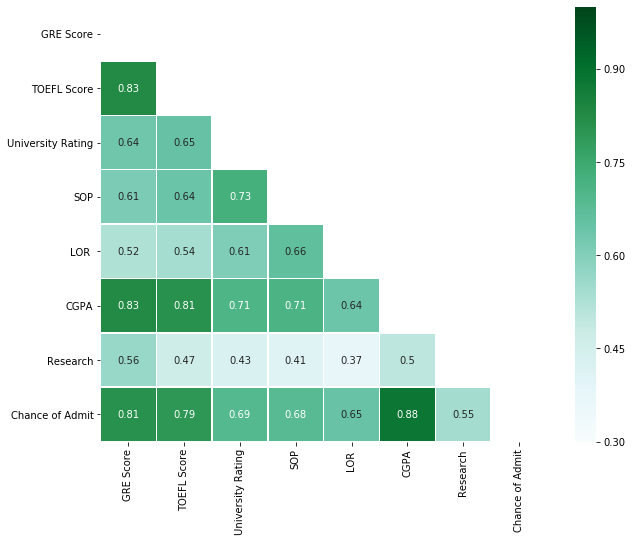

```python
import seaborn as sns
import matplotlib.pyplot as plt

plt.figure(figsize=(10, 8))

mask = np.zeros_like(df.corr())
mask[np.triu_indices_from(mask)] = True
ax = sns.heatmap(df.corr(), 0.3, 1, annot=True, linewidths=.5, cmap="BuGn", mask = mask)
```

### 2-다. "Research" 변수 분석 : Pairplot 함수 이용

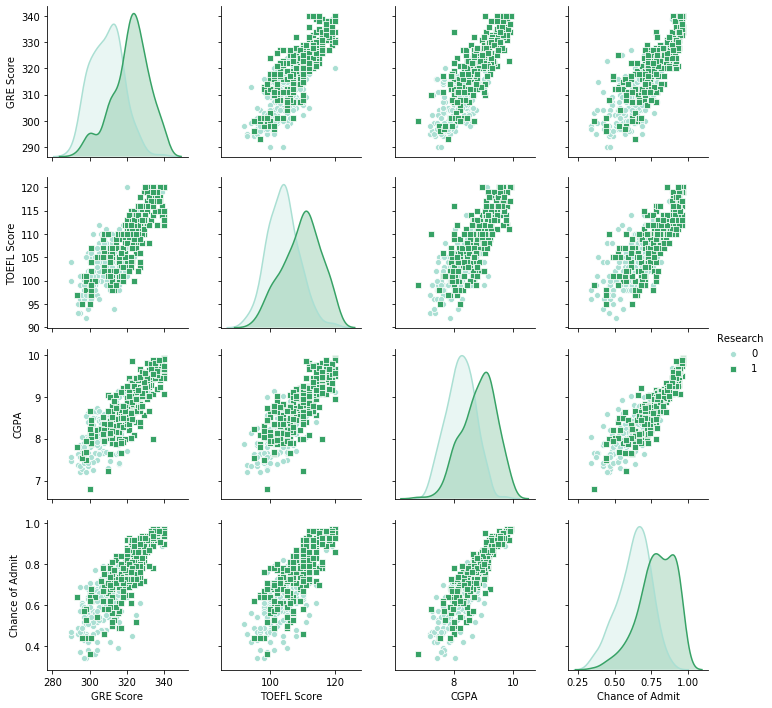

```python
plt.figure()

sns.pairplot(df, diag_kind='kde' , hue= "Research", vars=['GRE Score', 'TOEFL Score', 'CGPA', 'Chance of Admit'], palette="BuGn", markers=["o", "s"])
```

##### 리서치 유경험 학생들이 높은 시험 성적 경향이 높고, 입학 승인 가능성에서 다소 우위를 보이는 것으로 분석

# 3. 기계학습을 위한 데이터 전처리

## 3-가. 알고리즘 대입을 위한 변수 정하기

### 3-(1). 예측 분석용 데이터 테이블 주관적 가공

#### 너무 많은 독립변수는 선형 회귀분석의 과적함을 불러일으킬 수 있으므로 상관계수가 0.8에 근접하거나 이상인 변수들만 (임의로) 채택함

```python
Predictive_df = df[['GRE Score', 'TOEFL Score', 'CGPA', 'Chance of Admit']]

#Linear Regression 을 위한 dataframe 이 생성되었음을 확인
Predictive_df
```

|  | GRE Score | TOEFL Score | CGPA | Chance of Admit |
| --- | --- | --- | --- | --- |
| 0 | 337 | 118 | 9.65 | 0.92 |
| 1 | 324 | 107 | 8.87 | 0.76 |
| 2 | 316 | 104 | 8.00 | 0.72 |
| 3 | 322 | 110 | 8.67 | 0.80 |
| 4 | 314 | 103 | 8.21 | 0.65 |
| ... | ... | ... | ... | ... |
| 495 | 332 | 108 | 9.02 | 0.87 |
| 496 | 337 | 117 | 9.87 | 0.96 |
| 497 | 330 | 120 | 9.56 | 0.93 |
| 498 | 312 | 103 | 8.43 | 0.73 |
| 499 | 327 | 113 | 9.04 | 0.84 |

500 rows × 4 columns

## 3-(2). 변수 선택 방법으로 변수 정하기 - Forward Selection

#### 주관적인 견해가 들어가지 않는 변수 선택 알고리즘을 통한 변수 선택하기

```python
import statsmodels.api as sm
import matplotlib.pyplot as plt
import warnings
warnings.filterwarnings("ignore", category=FutureWarning)


before_selection = df.columns[:-1].tolist()

Y = df['Chance of Admit']
after_selection = []
criteria = 0.05

while len(before_selection ) > 0:
    remaining_selection = list(set(before_selection) - set(after_selection))
    p_value = pd.Series(index=remaining_selection)

    for col in remaining_selection:
        X = df[after_selection+[col]]
        X = sm.add_constant(X)
        model = sm.OLS(Y,X).fit()
        p_value[col] = model.pvalues[col]
    min_p_value = p_value.min()

    if min_p_value < criteria:
        after_selection.append(p_value.idxmin())

    else:
        break

after_selection
```

```
['CGPA', 'GRE Score', 'LOR ', 'Research', 'TOEFL Score']
```

### 3-(3). 변수 선택 방법으로 변수 정하기 - Backward Selection

```python
considering_variables = df.columns[:-1].tolist()

Y = df['Chance of Admit']
after_selection = considering_variables
criteria = 0.05

while len(considering_variables) > 0:
    X = sm.add_constant(df[after_selection])
    p_value = sm.OLS(Y,X).fit().pvalues[1:]
    max_p_value = p_value.max()
    if max_p_value >= criteria:
        removed_variables = p_value.idxmax()
        after_selection.remove(removed_variables)

    else:
        break

after_selection
```

```
['GRE Score', 'TOEFL Score', 'LOR ', 'CGPA', 'Research']
```

### 3-(4). 변수 선택 방법으로 변수 정하기 - Stepwise Selection

```python
considering_variables = df.columns[:-1].tolist()

Y = df['Chance of Admit']
after_selection = []
criteria = 0.05

while len(considering_variables) > 0:
    remaining_selection = list(set(considering_variables) - set(after_selection))
    p_value = pd.Series(index=remaining_selection)
    for col in remaining_selection:
        X = df[after_selection+[col]]
        X = sm.add_constant(X)
        model = sm.OLS(Y,X).fit()
        p_value[col] = model.pvalues[col]

    min_p_value = p_value.min()
    if min_p_value < criteria:
        after_selection.append(p_value.idxmin())

        while len(after_selection) > 0:
            after_X = df[after_selection]
            after_X = sm.add_constant(after_X)
            after_p_value = sm.OLS(Y,after_X).fit().pvalues[1:]
            max_p_value = after_p_value.max()
            if max_p_value >= criteria:
                removed_variables = after_p_value.idxmax()
                after_selection.remove(removed_variables)
            else:
                break

    else:
        break

after_selection
```

```
['CGPA', 'GRE Score', 'LOR ', 'Research', 'TOEFL Score']
```

### 3-(5). 변수 선택 방법 요약

```python
import pandas as pd

selections = {'Forward Selection' : ['CGPA', 'GRE Score', 'LOR ', 'Research', 'TOEFL Score'],
              'Backward Selection' : ['GRE Score', 'TOEFL Score', 'LOR ', 'CGPA', 'Research'],
              'Stepwise Selection' : ['CGPA', 'GRE Score', 'LOR ', 'Research', 'TOEFL Score']
             }

SelectionMethod_df = pd.DataFrame(selections, columns = ['Forward Selection', 'Backward Selection', 'Stepwise Selection'],
                                                         index=['1st', '2nd', '3rd', '4th', '5th'])

SelectionMethod_df.style
```

|  | Forward Selection | Backward Selection | Stepwise Selection |
| --- | --- | --- | --- |
| 1st | CGPA | GRE Score | CGPA |
| 2nd | GRE Score | TOEFL Score | GRE Score |
| 3rd | LOR | LOR | LOR |
| 4th | Research | CGPA | Research |
| 5th | TOEFL Score | Research | TOEFL Score |

#### 결론적으로 university rating 및 SOP를 제외한 변수들 생존하였고 주관적 평가 요소인 LOR 변수는 제외 후 분석 예정

### 3-나. Training & Test Dataset Splitting

```python
from sklearn.model_selection import train_test_split

X = Predictive_df.iloc[:, 0:3]
Y = Predictive_df.iloc[:, 3]

X_train, X_test, Y_train, Y_test = train_test_split(X, Y, test_size= 0.30, random_state=123123)
```

## 4. 데이터 분석 (Predictive/Estimation Analysis)

### 4-(1) Linear Regression Without Scaling

```python
from sklearn.linear_model import LinearRegression
from sklearn.metrics import r2_score
from sklearn.metrics import mean_squared_error as mse
import math

LR_reg = LinearRegression()
LR_reg.fit(X_train, Y_train)

Y_pred = LR_reg.predict(X_test)


LR_rScore  = r2_score(Y_test, Y_pred)
LR_rScore_r = round(LR_rScore, 6)
print("R square score for Linear Regression is : " + str(LR_rScore_r))

LR_error = mse(Y_test, Y_pred)
LR_error_r = round(LR_error, 6)
print("Mean Squared Error for Linear Regression is :" + str(LR_error_r))

LR_sq_error = math.sqrt(LR_error_r)
LR_sq_error_r = round(LR_sq_error, 6)
print("Root Mean Squared Error for Linear Regression is :" + str(LR_sq_error_r))

LR_Y_pred = Y_pred
LinRegChart = pd.DataFrame()
LinRegChart['예측값'] = np.round(Y_pred, 4)
LinRegChart['실제값'] = np.array(Y_test)
LinRegChart.head(10)
```

```
R square score for Linear Regression is : 0.846467
Mean Squared Error for Linear Regression is :0.00318
Root Mean Squared Error for Linear Regression is :0.056391
```

|  | 예측값 | 실제값 |
| --- | --- | --- |
| 0 | 0.7510 | 0.77 |
| 1 | 0.5602 | 0.59 |
| 2 | 0.7525 | 0.77 |
| 3 | 0.6261 | 0.64 |
| 4 | 0.8367 | 0.82 |
| 5 | 0.8928 | 0.93 |
| 6 | 0.7365 | 0.84 |
| 7 | 0.6367 | 0.65 |
| 8 | 0.7540 | 0.71 |
| 9 | 0.8215 | 0.87 |

### 4-(2) Decision Tree Regression Without Scaling

```python
from sklearn.tree import DecisionTreeRegressor

DT_reg = DecisionTreeRegressor(random_state = 8282)
DT_reg.fit(X_train, Y_train)

Y_pred = DT_reg.predict(X_test)


DT_rScore = r2_score(Y_test, Y_pred)
DT_rScore_r = round(DT_rScore, 6)
print("R square score for Decision Tree Regression is : " + str(DT_rScore_r))


DT_error = mse(Y_test, Y_pred)
DT_error_r = round(DT_error, 6)
print("Mean Squared Error for Decision Tree Regression is :" + str(DT_error_r))


DT_sq_error = math.sqrt(DT_error_r)
DT_sq_error_r = round(DT_sq_error, 6)
print("Root Mean Squared Error for Decision Tree Regression is :" + str(DT_sq_error_r))

DTChart = pd.DataFrame()
DTChart['예측값'] = np.round(Y_pred, 4)
DTChart['실제값'] = np.array(Y_test)
DTChart.head(10)
```

```
R square score for Decision Tree Regression is : 0.678144
Mean Squared Error for Decision Tree Regression is :0.006665
Root Mean Squared Error for Decision Tree Regression is :0.081639
```

|  | 예측값 | 실제값 |
| --- | --- | --- |
| 0 | 0.81 | 0.77 |
| 1 | 0.63 | 0.59 |
| 2 | 0.74 | 0.77 |
| 3 | 0.73 | 0.64 |
| 4 | 0.84 | 0.82 |
| 5 | 0.92 | 0.93 |
| 6 | 0.71 | 0.84 |
| 7 | 0.62 | 0.65 |
| 8 | 0.78 | 0.71 |
| 9 | 0.86 | 0.87 |

### 4-(3) Random Forest Regression Without Scaling

```python
from sklearn.ensemble import RandomForestRegressor
import warnings
warnings.filterwarnings("ignore", category=FutureWarning)


RFR_reg = RandomForestRegressor(random_state = 8282)
RFR_reg.fit(X_train, Y_train)

Y_pred = RFR_reg.predict(X_test)


RFR_rScore = r2_score(Y_test, Y_pred)
RFR_rScore_r = round(RFR_rScore, 6)
print("R square score for Random Forest Regression is : " + str(RFR_rScore_r))


RFR_error = mse(Y_test, Y_pred)
RFR_error_r = round(RFR_error, 6)
print("Mean Squared Error for Random Forest Regression is :" + str(RFR_error_r))


RFR_sq_error = math.sqrt(RFR_error_r)
RFR_sq_error_r = round(RFR_sq_error, 6)
print("Root Mean Squared Error for Random Forest Regression is :" + str(RFR_sq_error_r))

RFRChart = pd.DataFrame()
RFRChart['예측값'] = np.round(Y_pred, 4)
RFRChart['실제값'] = np.array(Y_test)
RFRChart.head(10)
```

```
R square score for Random Forest Regression is : 0.805673
Mean Squared Error for Random Forest Regression is :0.004024
Root Mean Squared Error for Random Forest Regression is :0.063435
```

|  | 예측값 | 실제값 |
| --- | --- | --- |
| 0 | 0.720 | 0.77 |
| 1 | 0.642 | 0.59 |
| 2 | 0.723 | 0.77 |
| 3 | 0.663 | 0.64 |
| 4 | 0.826 | 0.82 |
| 5 | 0.911 | 0.93 |
| 6 | 0.690 | 0.84 |
| 7 | 0.618 | 0.65 |
| 8 | 0.735 | 0.71 |
| 9 | 0.801 | 0.87 |

### 4-더미 Scaling Data With MinMaxScaler

```python
from sklearn.preprocessing import MinMaxScaler

# we do scaling after Training & Testing data split because data leakage might happen

scaler = MinMaxScaler(feature_range = (0, 1))
X_train = scaler.fit_transform(X_train)
X_test = scaler.fit_transform(X_test)
```

### 4-(4) Linear Regression With Scaling

```python
LR_reg_o = LinearRegression()
LR_reg_o.fit(X_train, Y_train)

Y_pred = LR_reg_o.predict(X_test)


LR_rScore  = r2_score(Y_test, Y_pred)
LR_rScore_r_o = round(LR_rScore, 6)
print("R square score for Linear Regression is : " + str(LR_rScore_r_o))


LR_error = mse(Y_test, Y_pred)
LR_error_r_o = round(LR_error, 6)
print("Mean Squared Error for Linear Regression is :" + str(LR_error_r_o))

LR_sq_error = math.sqrt(LR_error_r_o)
LR_sq_error_r_o = round(LR_sq_error, 6)
print("Root Mean Squared Error for Linear Regression is :" + str(LR_sq_error_r_o))


LinRegChart = pd.DataFrame()
LinRegChart['예측값'] = np.round(Y_pred, 4)
LinRegChart['실제값'] = np.array(Y_test)
LinRegChart.head(10)
```

```
R square score for Linear Regression is : 0.835491
Mean Squared Error for Linear Regression is :0.003407
Root Mean Squared Error for Linear Regression is :0.05837
```

|  | 예측값 | 실제값 |
| --- | --- | --- |
| 0 | 0.7579 | 0.77 |
| 1 | 0.5793 | 0.59 |
| 2 | 0.7604 | 0.77 |
| 3 | 0.6506 | 0.64 |
| 4 | 0.8394 | 0.82 |
| 5 | 0.8937 | 0.93 |
| 6 | 0.7455 | 0.84 |
| 7 | 0.6480 | 0.65 |
| 8 | 0.7653 | 0.71 |
| 9 | 0.8267 | 0.87 |

### 4-(5) Decision Tree Regression With Scaling

```python
DT_reg = DecisionTreeRegressor(random_state = 8282)
DT_reg.fit(X_train, Y_train)

Y_pred = DT_reg.predict(X_test)


DT_rScore = r2_score(Y_test, Y_pred)
DT_rScore_r_o = round(DT_rScore, 6)
print("R square score for Decision Tree Regression is : " + str(DT_rScore_r_o))


DT_error = mse(Y_test, Y_pred)
DT_error_r_o = round(DT_error, 6)
print("Mean Squared Error for Decision Tree Regression is :" + str(DT_error_r_o))


DT_sq_error = math.sqrt(DT_error_r_o)
DT_sq_error_r_o = round(DT_sq_error, 6)
print("Root Mean Squared Error for Decision Tree Regression is :" + str(DT_sq_error_r_o))

DTChart = pd.DataFrame()
DTChart['예측값'] = np.round(Y_pred, 4)
DTChart['실제값'] = np.array(Y_test)
DTChart.head(10)
```

```
R square score for Decision Tree Regression is : 0.531477
Mean Squared Error for Decision Tree Regression is :0.009703
Root Mean Squared Error for Decision Tree Regression is :0.098504
```

|  | 예측값 | 실제값 |
| --- | --- | --- |
| 0 | 0.55 | 0.77 |
| 1 | 0.34 | 0.59 |
| 2 | 0.85 | 0.77 |
| 3 | 0.67 | 0.64 |
| 4 | 0.88 | 0.82 |
| 5 | 0.91 | 0.93 |
| 6 | 0.63 | 0.84 |
| 7 | 0.62 | 0.65 |
| 8 | 0.79 | 0.71 |
| 9 | 0.78 | 0.87 |

### 4-(6) Random Forest Regression With Scaling

```python
RFR_reg = RandomForestRegressor(random_state = 8282)
RFR_reg.fit(X_train, Y_train)

Y_pred = RFR_reg.predict(X_test)


RFR_rScore = r2_score(Y_test, Y_pred)
RFR_rScore_r_o = round(RFR_rScore, 6)
print("R square score for Random Forest Regression is : " + str(RFR_rScore_r_o))


RFR_error = mse(Y_test, Y_pred)
RFR_error_r_o = round(RFR_error, 6)
print("Mean Squared Error for Random Forest Regression is :" + str(RFR_error_r_o))


RFR_sq_error = math.sqrt(RFR_error_r_o)
RFR_sq_error_r_o = round(RFR_sq_error, 6)
print("Root Mean Squared Error for Random Forest Regression is :" + str(RFR_sq_error_r_o))

RFRChart = pd.DataFrame()
RFRChart['예측값'] = np.round(Y_pred, 4)
RFRChart['실제값'] = np.array(Y_test)
RFRChart.head(10)
```

```
R square score for Random Forest Regression is : 0.758994
Mean Squared Error for Random Forest Regression is :0.004991
Root Mean Squared Error for Random Forest Regression is :0.070647
```

|  | 예측값 | 실제값 |
| --- | --- | --- |
| 0 | 0.739 | 0.77 |
| 1 | 0.544 | 0.59 |
| 2 | 0.766 | 0.77 |
| 3 | 0.643 | 0.64 |
| 4 | 0.871 | 0.82 |
| 5 | 0.910 | 0.93 |
| 6 | 0.707 | 0.84 |
| 7 | 0.579 | 0.65 |
| 8 | 0.681 | 0.71 |
| 9 | 0.804 | 0.87 |

### 4-가. 분석 결과 비교표 및 그래프

```python
data = {
        'Linear Regression w/o scaling': [LR_rScore_r, LR_error_r , LR_sq_error_r],
        'Linear Regression w/ scaling' : [LR_rScore_r_o, LR_error_r_o, LR_sq_error_r_o],
        'Random Forest w/o scaling' : [RFR_rScore_r, RFR_error_r, RFR_sq_error_r],
        'Random Forest w/ scaling' : [RFR_rScore_r_o, RFR_error_r_o, RFR_sq_error_r_o],
        'Decision Tree w/o scaling' : [DT_rScore_r, DT_error_r, DT_sq_error_r],
        'Decision Tree w/ scaling' : [DT_rScore_r_o, DT_error_r_o, DT_sq_error_r_o]
         }

summary_df = pd.DataFrame(data, columns = ['Linear Regression w/o scaling',
                                           'Linear Regression w/ scaling',
                                           'Random Forest w/o scaling',
                                            'Random Forest w/ scaling',
                                           'Decision Tree w/o scaling',
                                           'Decision Tree w/ scaling'], index = ['R Score', 'MSE', 'R_MSE'])

summary_df.style
```

|  | Linear Regression w/o scaling | Linear Regression w/ scaling | Random Forest w/o scaling | Random Forest w/ scaling | Decision Tree w/o scaling | Decision Tree w/ scaling |
| --- | --- | --- | --- | --- | --- | --- |
| R Score | 0.846467 | 0.835491 | 0.805673 | 0.758994 | 0.678144 | 0.531477 |
| MSE | 0.00318 | 0.003407 | 0.004024 | 0.004991 | 0.006665 | 0.009703 |
| R_MSE | 0.056391 | 0.05837 | 0.063435 | 0.070647 | 0.081639 | 0.098504 |

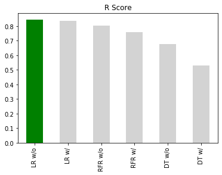

```python
RegressBar = pd.DataFrame(
    {'R Score': [LR_rScore_r, LR_rScore_r_o, RFR_rScore_r, RFR_rScore_r_o, DT_rScore_r, DT_rScore_r_o]},
    index = ['LR w/o', 'LR w/', 'RFR w/o', 'RFR w/', 'DT w/o', 'DT w/'])

RegressBar['R Score'].plot(kind="bar", color =['green', 'lightgrey', 'lightgrey', 'lightgrey', 'lightgrey', 'lightgrey'])

plt.title("R Score")
```

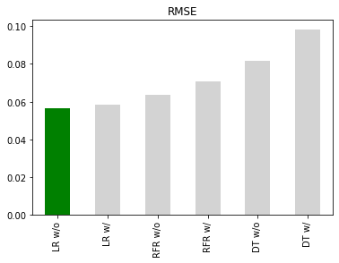

```python
RegressBar = pd.DataFrame(
    {'RMSE': [LR_sq_error_r, LR_sq_error_r_o, RFR_sq_error_r, RFR_sq_error_r_o, DT_sq_error_r, DT_sq_error_r_o]},
    index = ['LR w/o', 'LR w/', 'RFR w/o', 'RFR w/', 'DT w/o', 'DT w/'])

RegressBar['RMSE'].plot(kind="bar", color =['green', 'lightgrey', 'lightgrey', 'lightgrey', 'lightgrey', 'lightgrey'])

plt.title("RMSE")
```

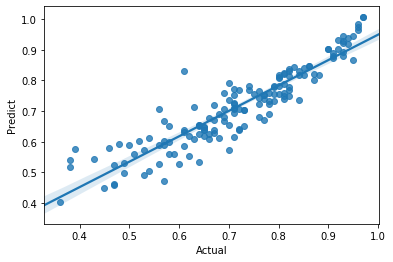

```python
x, y = pd.Series(Y_test, name="Actual"), pd.Series(LR_Y_pred, name="Predict")
ax = sns.regplot(x=x, y=y)
```

### 4-바. 합격 여부 예측하기 (가상 점수 입력)

```python
a = int(input ("Enter your GRE score (out of 340) : "))

b = int(input ("Enter your TOEFL score (out of 120) : "))

c = float(input ("Enter your College GPA score (out of 10 decimal place) : "))


print("Your likelihood for graduate school admission is : " )
print(LR_reg.predict([[a, b, c]]))
```

```
Enter your GRE score (out of 340) : 330
Enter your TOEFL score (out of 120) : 110
Enter your College GPA score (out of 10 decimal place) : 9
Your likelihood for graduate school admission is :
[0.82099384]
```

## 5. 데이터 분류 (Classification Method)

### 5-가. 데이터 칼럼 추가 (합격 여부 변수)

```python
def f(row):
    if row['Chance of Admit'] >= 0.8:
        val = 1
    else:
        val = 0
    return val


df['Admit Condition'] = df.apply(f, axis=1)

df


# In[]:


df['Admit Condition'].value_counts()
```

```
0    345
1    155
Name: Admit Condition, dtype: int64
```

#### 차후에 진행할 분류 알고리즘을 위해 Chance of Admit의 합격 승인 가능성을 확률이 80% 이상으로 의제하였고, 이 경우 총 155명의 지원자가 합격할 것으로 예측함

### 5-나. 분류용 데이터 테이블 만들기

```python
Classify_df = df[['GRE Score', 'TOEFL Score', 'CGPA', 'Admit Condition']]


Classify_df
```

|  | GRE Score | TOEFL Score | CGPA | Admit Condition |
| --- | --- | --- | --- | --- |
| 0 | 337 | 118 | 9.65 | 1 |
| 1 | 324 | 107 | 8.87 | 0 |
| 2 | 316 | 104 | 8.00 | 0 |
| 3 | 322 | 110 | 8.67 | 1 |
| 4 | 314 | 103 | 8.21 | 0 |
| ... | ... | ... | ... | ... |
| 495 | 332 | 108 | 9.02 | 1 |
| 496 | 337 | 117 | 9.87 | 1 |
| 497 | 330 | 120 | 9.56 | 1 |
| 498 | 312 | 103 | 8.43 | 0 |
| 499 | 327 | 113 | 9.04 | 1 |

500 rows × 4 columns

### 5-다. Training & Test Data Set Splitting

```python
X = Classify_df.iloc[:, 0:3]
Y = Classify_df.iloc[:, 3]

X_train, X_test, Y_train, Y_test = train_test_split(X, Y, test_size= 0.20, random_state=123123)
```

### 5-라. Scaling Data (Unnecessary)

As for most of the Classification algorithms, there are no significance benefit in scaling & enhancing data. *Except for K-NN method with is extremely sensitive to magnitudes of the provided features*

### 5-(1) Logistic Regression

```
Accuracy : 0.81
              precision    recall  f1-score   support

           0       0.81      0.94      0.87        66
           1       0.83      0.56      0.67        34

    accuracy                           0.81       100
   macro avg       0.82      0.75      0.77       100
weighted avg       0.81      0.81      0.80       100
```

|  | 예측값 | 실제값 |
| --- | --- | --- |
| 0 | 0 | 0 |
| 1 | 0 | 0 |
| 2 | 0 | 0 |
| 3 | 0 | 0 |
| 4 | 0 | 1 |
| ... | ... | ... |
| 95 | 0 | 1 |
| 96 | 0 | 0 |
| 97 | 1 | 1 |
| 98 | 0 | 1 |
| 99 | 0 | 0 |

100 rows × 2 columns

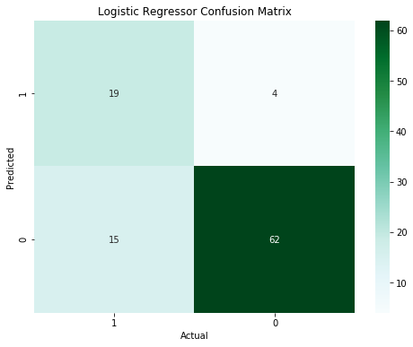

```python
from sklearn.linear_model import LogisticRegression
from sklearn import metrics
from sklearn.metrics import classification_report, confusion_matrix, accuracy_score

logreg = LogisticRegression()
logreg.fit(X_train, Y_train)
Y_pred = logreg.predict(X_test)


Log_Score = accuracy_score(Y_test, Y_pred)
print("Accuracy : " + str(Log_Score))

plt.figure(figsize=(8,6))

cm = confusion_matrix(Y_test, Y_pred)
tn, fp, fn, tp = confusion_matrix(Y_test, Y_pred).ravel()
cm = [[tp,fp],[fn,tn]]

LR_recall = tp / (tp + fn)
LR_spec = tn / (tn + fp)
LR_prec = tp / (tp + fn)
LR_accu = (tp + tn)/ (tp + tn + fp + fn)
LR_f1 = (2 * tp) / (2 * tp + fp + fn)
LR_tn = tn
LR_tp = tp
LR_fn = fn
LR_fp = fp

sns.heatmap(cm, annot = True, fmt = "d", cmap="BuGn")
plt.xticks([0.5, 1.5], labels=[1,0])
plt.yticks([0.5, 1.5], labels=[1,0])
plt.title('Logistic Regressor Confusion Matrix')
plt.xlabel('Actual')
plt.ylabel('Predicted')

report = classification_report(Y_test, Y_pred)
print(report)

LRChart = pd.DataFrame()
LRChart['예측값'] = np.round(Y_pred)
LRChart['실제값'] = np.array(Y_test)
LRChart.loc[::1]
```

### 5-(2) Decision Tree Classifier

```
Accuracy : 0.81
              precision    recall  f1-score   support

           0       0.81      0.92      0.87        66
           1       0.80      0.59      0.68        34

    accuracy                           0.81       100
   macro avg       0.81      0.76      0.77       100
weighted avg       0.81      0.81      0.80       100
```

|  | 예측값 | 실제값 |
| --- | --- | --- |
| 0 | 0 | 0 |
| 1 | 0 | 0 |
| 2 | 0 | 0 |
| 3 | 0 | 0 |
| 4 | 1 | 1 |
| ... | ... | ... |
| 95 | 0 | 1 |
| 96 | 1 | 0 |
| 97 | 1 | 1 |
| 98 | 1 | 1 |
| 99 | 0 | 0 |

100 rows × 2 columns

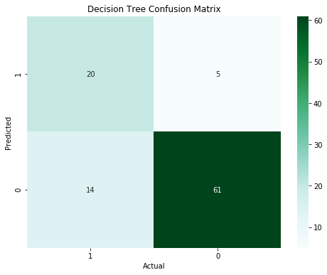

```python
from sklearn.tree import DecisionTreeClassifier

tree = DecisionTreeClassifier()
tree.fit(X_train, Y_train)
Y_pred = tree.predict(X_test)

tree_score = accuracy_score(Y_test, Y_pred)
print("Accuracy : " + str(tree_score))


plt.figure(figsize=(8,6))

cm = confusion_matrix(Y_test, Y_pred)
tn, fp, fn, tp = confusion_matrix(Y_test, Y_pred).ravel()
cm = [[tp,fp],[fn,tn]]

DT_recall = tp / (tp + fn)
DT_spec = tn / (tn + fp)
DT_prec = tp / (tp + fn)
DT_accu = (tp + tn)/ (tp + tn + fp + fn)
DT_f1 = (2 * tp) / (2 * tp + fp + fn)
DT_tn = tn
DT_tp = tp
DT_fn = fn
DT_fp = fp

sns.heatmap(cm, annot = True, fmt = "d", cmap="BuGn")
plt.xticks([0.5, 1.5], labels=[1,0])
plt.yticks([0.5, 1.5], labels=[1,0])
plt.title('Decision Tree Confusion Matrix')
plt.xlabel('Actual')
plt.ylabel('Predicted')

report = classification_report(Y_test, Y_pred)
print(report)

DTChart = pd.DataFrame()
DTChart['예측값'] = np.round(Y_pred)
DTChart['실제값'] = np.array(Y_test)
DTChart.loc[::1]
```

### 5-(3). Random Forest Classifier

```
Accuracy : 0.87
              precision    recall  f1-score   support

           0       0.85      0.97      0.91        66
           1       0.92      0.68      0.78        34

    accuracy                           0.87       100
   macro avg       0.89      0.82      0.84       100
weighted avg       0.88      0.87      0.86       100
```

|  | 예측값 | 실제값 |
| --- | --- | --- |
| 0 | 0 | 0 |
| 1 | 0 | 0 |
| 2 | 0 | 0 |
| 3 | 0 | 0 |
| 4 | 1 | 1 |
| ... | ... | ... |
| 95 | 0 | 1 |
| 96 | 0 | 0 |
| 97 | 1 | 1 |
| 98 | 0 | 1 |
| 99 | 0 | 0 |

100 rows × 2 columns

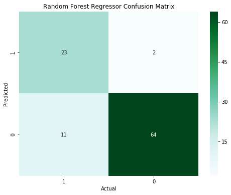

```python
from sklearn.ensemble import RandomForestClassifier


Forest_reg = RandomForestClassifier(n_estimators=500, random_state=123123)
Forest_reg.fit(X_train, Y_train)
Y_pred = Forest_reg.predict(X_test)



Forest_Score = accuracy_score(Y_test, Y_pred.round())
Forest_Score_r = round(Forest_Score, 6)
print("Accuracy : " + str(Forest_Score_r))


plt.figure(figsize=(8,6))


cm = confusion_matrix(Y_test, Y_pred.round())
tn, fp, fn, tp = confusion_matrix(Y_test, Y_pred.round()).ravel()
cm = [[tp,fp],[fn,tn]]

RF_recall = tp / (tp + fn)
RF_spec = tn / (tn + fp)
RF_prec = tp / (tp + fn)
RF_accu = (tp + tn)/ (tp + tn + fp + fn)
RF_f1 = (2 * tp) / (2 * tp + fp + fn)
RF_tn = tn
RF_tp = tp
RF_fn = fn
RF_fp = fp

sns.heatmap(cm, annot = True, fmt = "d", cmap="BuGn")
plt.xticks([0.5, 1.5], labels=[1,0])
plt.yticks([0.5, 1.5], labels=[1,0])
plt.title('Random Forest Regressor Confusion Matrix')
plt.xlabel('Actual')
plt.ylabel('Predicted')

report = classification_report(Y_test, Y_pred.round())
print(report)

RFChart = pd.DataFrame()
RFChart['예측값'] = np.round(Y_pred)
RFChart['실제값'] = np.array(Y_test)
RFChart.loc[::1]
```

### 5-(4). Naïve Bayes Classifier

```
Accuracy : 0.93
              precision    recall  f1-score   support

           0       0.94      0.95      0.95        66
           1       0.91      0.88      0.90        34

    accuracy                           0.93       100
   macro avg       0.92      0.92      0.92       100
weighted avg       0.93      0.93      0.93       100
```

|  | 예측값 | 실제값 |
| --- | --- | --- |
| 0 | 0 | 0 |
| 1 | 0 | 0 |
| 2 | 0 | 0 |
| 3 | 0 | 0 |
| 4 | 1 | 1 |
| ... | ... | ... |
| 95 | 1 | 1 |
| 96 | 0 | 0 |
| 97 | 1 | 1 |
| 98 | 0 | 1 |
| 99 | 0 | 0 |

100 rows × 2 columns

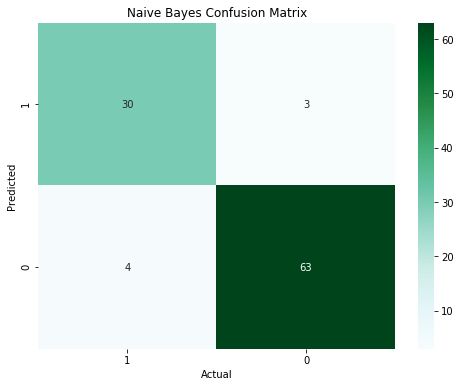

```python
from sklearn.naive_bayes import GaussianNB

NB_classifier = GaussianNB()
NB_classifier.fit(X_train, Y_train)
Y_pred = NB_classifier.predict(X_test)

NB_score = accuracy_score(Y_test, Y_pred)
print("Accuracy : " + str(NB_score))

plt.figure(figsize=(8,6))

cm = confusion_matrix(Y_test, Y_pred)
tn, fp, fn, tp = confusion_matrix(Y_test, Y_pred).ravel()
cm = [[tp,fp],[fn,tn]]

NB_recall = tp / (tp + fn)
NB_spec = tn / (tn + fp)
NB_prec = tp / (tp + fn)
NB_accu = (tp + tn)/ (tp + tn + fp + fn)
NB_f1 = (2 * tp) / (2 * tp + fp + fn)
NB_tn = tn
NB_tp = tp
NB_fn = fn
NB_fp = fp


sns.heatmap(cm, annot = True, fmt = "d", cmap="BuGn")
plt.xticks([0.5, 1.5], labels=[1,0])
plt.yticks([0.5, 1.5], labels=[1,0])
plt.title('Naive Bayes Confusion Matrix')
plt.xlabel('Actual')
plt.ylabel('Predicted')

report = classification_report(Y_test, Y_pred)
print(report)

NBChart = pd.DataFrame()
NBChart['예측값'] = np.round(Y_pred)
NBChart['실제값'] = np.array(Y_test)
NBChart.loc[::1]
```

### 5-(5). Support Vector Machine

```
Accuracy : 0.93
              precision    recall  f1-score   support

           0       0.92      0.98      0.95        66
           1       0.97      0.82      0.89        34

    accuracy                           0.93       100
   macro avg       0.94      0.90      0.92       100
weighted avg       0.93      0.93      0.93       100
```

|  | 예측값 | 실제값 |
| --- | --- | --- |
| 0 | 0 | 0 |
| 1 | 0 | 0 |
| 2 | 0 | 0 |
| 3 | 0 | 0 |
| 4 | 1 | 1 |
| ... | ... | ... |
| 95 | 0 | 1 |
| 96 | 0 | 0 |
| 97 | 1 | 1 |
| 98 | 0 | 1 |
| 99 | 0 | 0 |

100 rows × 2 columns

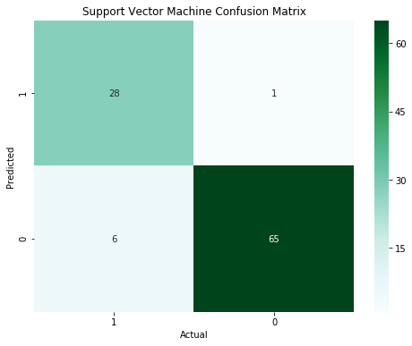

```python
from sklearn.svm import SVC

SVM_classifier = SVC(kernel = 'linear')
SVM_classifier.fit(X_train, Y_train)
Y_pred = SVM_classifier.predict(X_test)

SVM_score = accuracy_score(Y_test, Y_pred)
print("Accuracy : " + str(SVM_score))


plt.figure(figsize=(8,6))

cm = confusion_matrix(Y_test, Y_pred)
tn, fp, fn, tp = confusion_matrix(Y_test, Y_pred).ravel()
cm = [[tp,fp],[fn,tn]]

SVM_recall = tp / (tp + fn)
SVM_spec = tn / (tn + fp)
SVM_prec = tp / (tp + fn)
SVM_accu = (tp + tn)/ (tp + tn + fp + fn)
SVM_f1 = (2 * tp) / (2 * tp + fp + fn)
SVM_tn = tn
SVM_tp = tp
SVM_fn = fn
SVM_fp = fp



sns.heatmap(cm, annot = True, fmt = "d", cmap="BuGn")
plt.xticks([0.5, 1.5], labels=[1,0])
plt.yticks([0.5, 1.5], labels=[1,0])
plt.title('Support Vector Machine Confusion Matrix')
plt.xlabel('Actual')
plt.ylabel('Predicted')

report = classification_report(Y_test, Y_pred)
print(report)

SVMChart = pd.DataFrame()
SVMChart['예측값'] = np.round(Y_pred)
SVMChart['실제값'] = np.array(Y_test)
SVMChart.loc[::1]
```

### 5-마. 분류 결과 비교표 및 그래프

```python
class_data = {
        'Random Forest': [RF_tn, RF_tp, RF_fn, RF_fp, RF_recall, RF_spec, RF_prec, RF_accu, RF_f1],
        'Log Regression' : [LR_tn, LR_tp, LR_fn, LR_fp, LR_recall, LR_spec, LR_prec, LR_accu, LR_f1],
        'Decision Tree' : [DT_tn, DT_tp, DT_fn, DT_fp, DT_recall, DT_spec, DT_prec, DT_accu, DT_f1],
        'Naive Bayes' : [NB_tn, NB_tp, NB_fn, NB_fp, NB_recall, NB_spec, NB_prec, NB_accu, NB_f1],
        'SVM' : [SVM_tn, SVM_tp, SVM_fn, SVM_fp, SVM_recall, SVM_spec, SVM_prec, SVM_accu, SVM_f1]
         }

class_summary_df = pd.DataFrame(class_data, columns = ['Random Forest',
                                           'Log Regression',
                                           'Decision Tree',
                                            'Naive Bayes',
                                           'SVM'], index = ['TN', 'TP', 'FN', 'FP', 'Recall', 'Specificity', 'Precision', 'Accuracy', 'F1 score'])

class_summary_df.style
```

[output not shown]

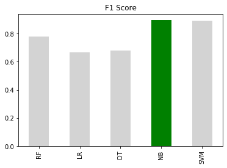

```python
ClassBar = pd.DataFrame(
    {'F1 Score': [RF_f1, LR_f1, DT_f1, NB_f1, SVM_f1]},
    index = ['RF', 'LR', 'DT', 'NB', 'SVM'])

ClassBar['F1 Score'].plot(kind="bar", color =['lightgrey', 'lightgrey', 'lightgrey', 'green', 'lightgrey', 'lightgrey'])

plt.title("F1 Score")
```

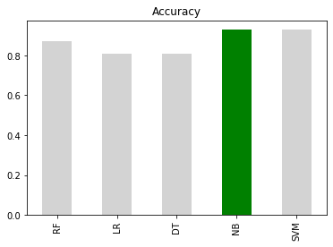

```python
ClassBar = pd.DataFrame(
    {'Accuracy': [RF_accu, LR_accu, DT_accu, NB_accu, SVM_accu]},
    index = ['RF', 'LR', 'DT', 'NB', 'SVM'])

ClassBar['Accuracy'].plot(kind="bar", color =['lightgrey', 'lightgrey', 'lightgrey', 'green', 'lightgrey', 'lightgrey'])

plt.title("Accuracy")
```

### 5-바. 합격 여부 예측하기 (가상 점수 입력)

```python
aa = int(input ("Enter your GRE score (out of 340) : "))

bb = int(input ("Enter your TOEFL score (out of 120) : "))

cc = float(input ("Enter your College GPA score (out of 10 decimal place) : "))



if NB_classifier.predict([[aa, bb, cc]]) == 1:
    print("Congrats! You are admitted!")
else:
    print("We regret to inform you that your application is no longer under consideration")


print(NB_classifier.predict([[aa, bb, cc]]))
```

```
Enter your GRE score (out of 340) : 330
Enter your TOEFL score (out of 120) : 110
Enter your College GPA score (out of 10 decimal place) : 9
Congrats! You are admitted!
[1]
```

```python
aa = int(input ("Enter your GRE score (out of 340) : "))

bb = int(input ("Enter your TOEFL score (out of 120) : "))

cc = float(input ("Enter your College GPA score (out of 10 decimal place) : "))



if NB_classifier.predict([[aa, bb, cc]]) == 1:
    print("Congrats! You are admitted!")
else:
    print("We regret to inform you that your application is no longer under consideration")


print(NB_classifier.predict([[aa, bb, cc]]))
```

```
Enter your GRE score (out of 340) : 200
Enter your TOEFL score (out of 120) : 90
Enter your College GPA score (out of 10 decimal place) : 5
We regret to inform you that your application is no longer under consideration
[0]
```